# Rapport R

Fatou Seye

03/11/2021

### Cette base de données porte sur la pollution en plastique et elle vient de l’association Break Free From Plastic. Cette dernière lutte contre la pollution, notamment les déchets plastiques qui sont rejetés par les grandes entreprises de fabrication. Ce sujet est très intéressant, il est d’ailleurs toujours d’actualité, on va ainsi faire des manipulations avec cette de données pour en aprrendre plus sur la pollution en plastique pendant les années 2019 et 2020.

```r
library(tidytuesdayR)
library(tidyverse)
```

### Importation des données :

```r
tuesdata <- tidytuesdayR::tt_load('2021-01-26')
```

```
## --- Compiling #TidyTuesday Information for 2021-01-26 ----
```

```
## --- There is 1 file available ---
```

```
## --- Starting Download ---
```

```
## --- Download complete ---
```

```r
tuesdata <- tidytuesdayR::tt_load(2021, week = 5)
```

```
## --- Compiling #TidyTuesday Information for 2021-01-26 ----
```

```
## --- There is 1 file available ---
```

```
## --- Starting Download ---
```

```
## --- Download complete ---
```

```r
plastics <- tuesdata$plastics
```

# supprimons les valeurs manquantes

```r
df = na.omit(plastics)
```

## Questions :

### **1. Combien y a t-il de volontaires dans le mouvement Break Free From Plastic ?

```r
nb_vol<- df$volunteers
summary(nb_vol)
```

```
##    Min. 1st Qu.  Median    Mean 3rd Qu.    Max.
##       3     190     400    1477    2099    6850
```

### **2. Combien y a t-il de déchets plastiques en tout ?

```r
nb_dechet <- df %>%
  select(grand_total) %>%
  summary(grand_total)

nb_dechet
```

```
##   grand_total
##  Min.   :    0.00
##  1st Qu.:    1.00
##  Median :    2.00
##  Mean   :   93.45
##  3rd Qu.:    8.00
##  Max.   :80570.00
```

```r
nb_events <- summary(df$num_events)
```

### **4. Est ce qu’il y a un lien entre le nombre de déchet total et le nombre de volontaires ?

```r
df %>%
  mutate(n_vol = volunteers ) %>%
  drop_na(n_vol) -> corr_2
cor(corr_2$n_vol, with(corr_2, grand_total))
```

```
## [1] 0.003567757
```

### On voit que d’après notre résultat il y a presque pas de lien entre le nombre de volontaires dans le mouvement et le nombre de déchet total.

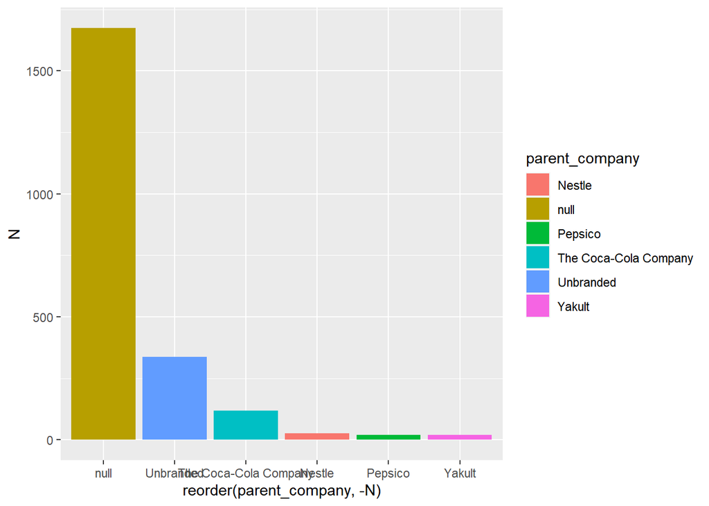

```r
df %>%
  filter(country == "Brazil") %>%
  group_by(parent_company) %>%
  summarize(N = max(grand_total)) %>%
  top_n(5) %>%
  ggplot()+
  aes(x= reorder(parent_company , -N), N, fill = parent_company)+
  geom_col()
```

### **6. Y’a t-il une corrélation entre les évenements de comptage et la quantité de déchets en plastiques?

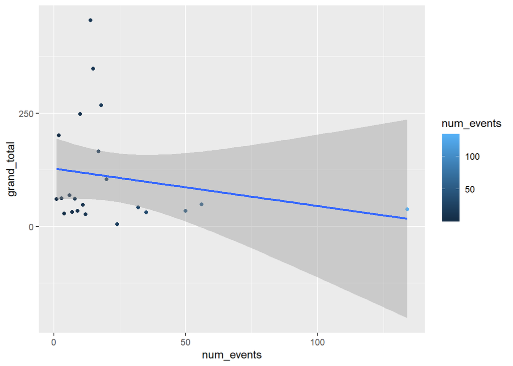

```r
df %>%
  group_by(num_events) %>%
  summarise(grand_total = mean(grand_total, na.rm = T)) %>%
  ggplot()+
  aes(num_events, grand_total , color = num_events)+
  geom_point()+
  geom_smooth(method = "lm")
```

### **7. Quelle est la proportion de la pollution de plastique dans ces 5 pays?

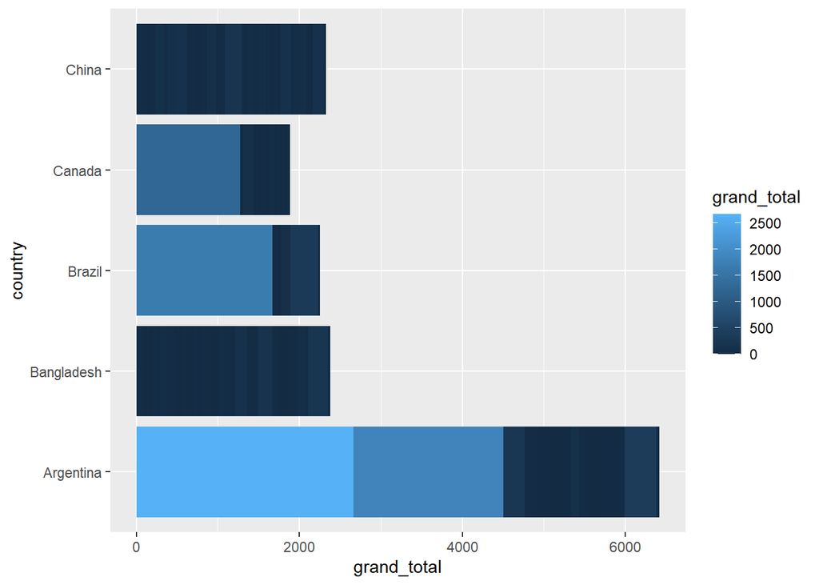

```r
df %>%
  filter(country %in% c( "Argentina" , "Brazil" , "Bangladesh", "China" ,"Canada")) %>%
  group_by(year) %>%
  ggplot()+
  aes(x = grand_total , y = country , fill = grand_total)+
  geom_col()
```

### **8. Quelle est la différence de participation entre les volontaires selon les pays?

```r
particip<- df %>%
  group_by(country , year) %>%
  summarise(y_events = mean(num_events, na.rm = TRUE) ,
            y_volunteers = mean(volunteers, na.rm = TRUE)) %>%
  pivot_wider(id = "country", names_from = "year", values_from = c("y_events" , "y_volunteers")) %>%
  ungroup() %>%
  mutate(dif_volunteers = y_volunteers_2020 - y_volunteers_2019 )
particip
```

```
## # A tibble: 55 x 6
##    country      y_events_2019 y_events_2020 y_volunteers_2019 y_volunteers_2020
##    <chr>                <dbl>         <dbl>             <dbl>             <dbl>
##  1 Argentina                4            24               243                 9
##  2 Armenia                 NA             2                NA                 6
##  3 Australia               NA             9                NA               190
##  4 Bangladesh              NA             1                NA               127
##  5 Benin                   NA             2                NA               458
##  6 Brazil                  NA             4                NA                78
##  7 Bulgaria                NA             7                NA                50
##  8 Burkina Faso            NA             1                NA               163
##  9 Canada                  NA             3                NA                13
## 10 Chile                   NA             3                NA                13
## # ... with 45 more rows, and 1 more variable: dif_volunteers <dbl>
```

```r
data<- df %>%
  filter(year == "2019" ) %>%
  group_by(country, grand_total) %>%
  summarize(N = n()) %>%
  top_n(20)
```

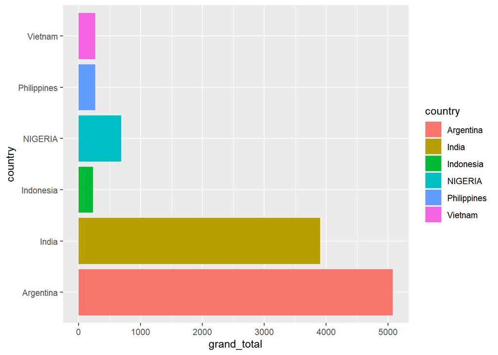

```r
data %>%
  ggplot()+
  aes(x = country , y = grand_total , fill = country)+
  geom_col()+
  coord_flip()
```

### **10. Quel est le pays qui pollue le plus en 2020?

```r
data2 <- df %>%
  filter(year == "2020" ) %>%
  group_by(country, grand_total) %>%
  summarize(N = n()) %>%
  top_n(20)
```

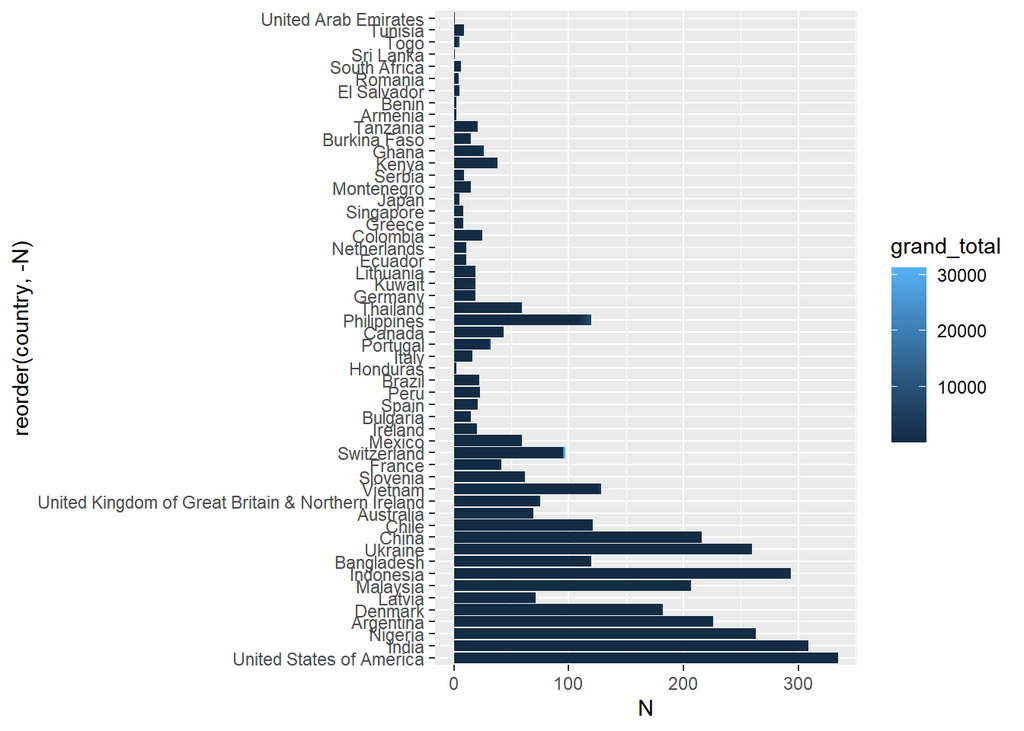

```r
data2 %>%
  ggplot()+
  aes(x = reorder(country , -N), N , fill = grand_total)+
  geom_col()+
  coord_flip()
```